# [8] Surgical prophylaxis (SP): WHO AWaRe QIs analysis against gPPS data

CNPI AMR

Last compiled on Sunday 05 October, 2025

# 📊 Report Overview

This report presents a summary of the AWaRe-based quality indicator analysis based on gPPS inpatient data for Surgical prophylaxis (SP).

This analytical script implements **WHO AWaRe (Access, Watch, Reserve)** antibiotic use **quality indicators (QIs)** for **SP** in adult inpatients. It utilises standardised data from the Global PPS (gPPS), specifically extracted from Excel-based outputs received by participating hospitals.

**Surgical prophylaxis** (Based on WHO AWaRe book)  
▸ **gPPS diagnostic code:** `Proph`(including all diagnostic codes)  
▸ **gPPS Indication:**`SP1,SP2,SP3`  
▸ **gPPS definition:** antibiotics given before/during/after surgical procedures

The aim is to assess the appropriateness of **empirical antibiotic prescribing** for surgical prophylaxis, benchmarked against WHO AWaRe Book, and to provide structured feedback at both the hospital and ward levels. These insights support **antimicrobial stewardship efforts** by highlighting patterns of suboptimal prescribing and identifying opportunities for targeted quality improvement.

## 🎯 WHO AWaRe QIs for surgical prophylaxis

Within the scope of the gPPS data structure, **one** QIs has been identified as compatible for evaluating surgical prophylaxis-related empirical antibiotic prescriptions in adults:

1. **H_SP_APPROP_ABX**: Proportion of patients given the appropriate IV surgical prophylaxis according to the WHO AWaRe book for any of the listed procedures: Bowel Surgery, Clean or Clean-Contaminated Procedure, Contaminated Procedure, Urologic Procedure

## 💬 General Notes:

- Analysis includes only **adult patients (≥18 years)** with **SP (1-3)** on **empirical** treatment.
- **Intravenous (IV) administration** was inferred using the gPPS `"Route"` code `"P"` (Parenteral), recognizing that it may include other parenteral routes but predominantly indicates IV use in empirical clinical practice.
- **Quality Indicators (QIs)** were mapped and interpreted based on clinical assumptions aligning WHO Book with the available **gPPS diagnostic codes**.
- We assumed that gPPS “prophylaxis **(SP1-SP3)**” indications for all diagnoses are eligible for the assessment against WHO AWaRe book.*

💡 **Reminder:** Caution is advised when interpreting results from small sample sizes (<10 patients)

# 🔍 Initial Data Check

This section assesses whether there are enough eligible cases to support meaningful analysis.

**📅 Survey period:** 01 Feb 2025 to 05 Feb 2025

This script applies **WHO AWaRe Quality Indicators** to adult inpatients who received empirical antibiotics for surgical prophylaxis (SP).

- **Diagnostic code:** Proph
- **Indication(s):** SP1, SP2, SP3
- **Total eligible cases:** 21

**✅ Good to go!** Sufficient eligible cases available to proceed with full evaluation.

# 🧾 Summary of SP Eligible Patients for QI Assessment

Eligible patients for **WHO AWaRe QI** assessment are defined as **adult inpatients (≥18 years)** who received **empirical antibiotics** as **surgical prohylaxis**.

This section presents both **prescription-level** and **patient-level** summaries to establish how much of the dataset is relevant for QI evaluation. It helps frame the proportion of all prescriptions that are relevant to SP.

## 👥 Patient-Level Summary

This table reports on unique patients in each eligibility group. It reflects the proportion of patients on surgical prophylaxis suitable for QI evaluation.

**📊 Summary:**  
Total number of patients on antibiotics: **205**  
Total number of eligible patients on antibiotics: **21**

| Patient Category | Number of Patients | Proportion of All Patients |
| --- | --- | --- |
| Number of all patients with any surgical prophylaxis (SP1–SP3) | 21 | 10.2% |
| Number of adult patients (≥18 years) who received empirical surgical prophylaxis | 21 | 10.2% |

## 📑 Prescription-Level Summary

**📊 Summary:**  
Total number of antibiotic prescriptions: **215**  
Total number of eligible antibiotic prescriptions: **21**

| Prescription Category | Number of Prescriptions | Proportion of All Prescriptions |
| --- | --- | --- |
| Number of all antibiotic prescriptions for surgical prophylaxis (SP1–SP3) | 21 | 9.7% |
| Number of empirical surgical prophylaxis prescriptions administered to adult patients (≥18 years) | 21 | 9.7% |

# 📘 WHO AWaRe-QIs Overview

This script evaluates **ONE** WHO AWaRe indicator:

1. **H_SP_APPROP_ABX**: Proportion of patients given the appropriate IV surgical prophylaxis according to the WHO AWaRe book for any of the listed procedures: Bowel Surgery, Clean or Clean-Contaminated Procedure, Contaminated Procedure, Urologic Procedure

**🔍 WHO AWaRe Book Recommendation:**

- **Bowel Surgery:** Cefazolin (2 g single dose IV) + Metronidazole (500 mg single dose IV) OR Amoxicillin+clavulanic acid (2 g+200 mg single dose IV)
- **Clean or Clean-Contaminated Procedure:** Cefazolin (2 g single dose IV) OR Cefuroxime (1.5 g single dose IV)
- **Urologic Procedure:** Cefazolin (2 g single dose IV) OR OR Gentamicin (5 mg/kg single dose IV)
- **Contaminated Procedure:** Cefazolin (2 g single dose IV) + Metronidazole (500 mg single dose IV) OR Amoxicillin+clavulanic acid (2 g+200 mg single dose IV) OR Gentamicin (5 mg/kg single dose IV) + Metronidazole (500 mg single dose IV)

**🩺 WHO AWaRe Notes:**

- Bowel surgery includes appendectomy, small intestine and colorectal surgical procedures
- Timing: 120 minutes or less before starting surgery
- If cloxacillin is unavailable, any other IV antistaphylococcal penicillin could be used.
- A higher dose (e.g. 12 g/day) could be considered given the concerns with bone penetration.
- Consider an additional dose only for prolonged procedures or if major blood loss
- Gentamicin should be given in combination with metronidazole because, if given alone, it provides insufficient coverage of anaerobic bacteria
- Antibiotic prophylaxis prior to dental surgeries is not addressed

# 📌 Indicator 1 – IV Antibiotic Appropriateness

> **H_SP_APPROP_ABX:** Proportion of patients given the appropriate IV surgical prophylaxis according to the WHO AWaRe book for any of the listed procedures: Bowel Surgery, Clean or Clean-Contaminated Procedure, Contaminated Procedure, Urologic Procedure

## 📈 SP Antibiotic Choice Appropriateness

This visual summarises the proportion of SP antibiotic appropriateness across hospital departments based on WHO AWaRe Book

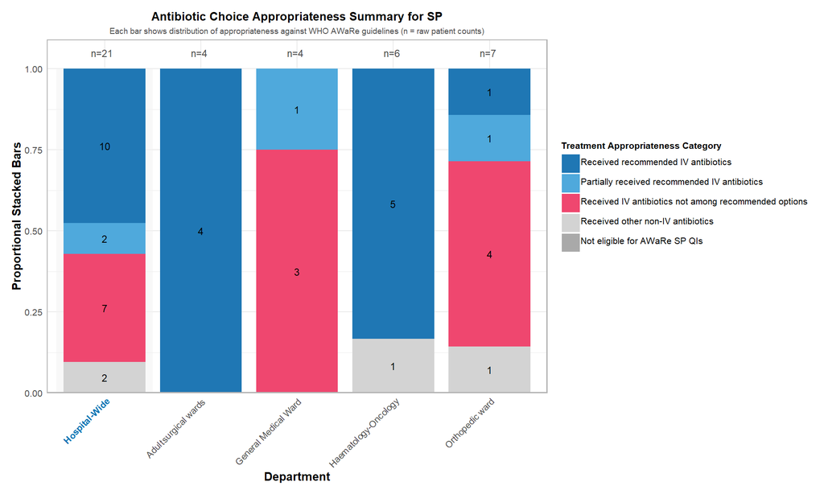

## 📈 Antibiotic Choice Appropriateness by AWaRe Classification

This visual summarises the proportion of SP antibiotic appropriateness across hospital departments by WHO AWaRe Classification (Access, Watch, Reserve)

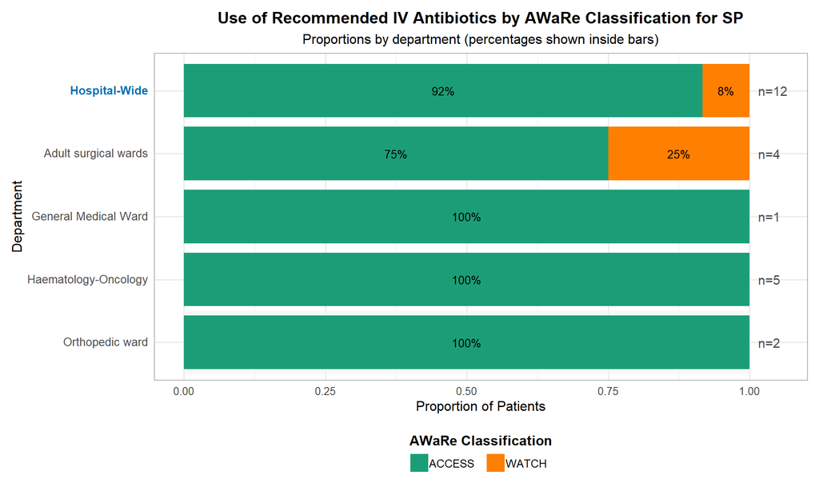

**💡 Note:** Each patient is counted once per AWaRe category if they received at least one recommended IV antibiotic from that category. Patients treated with recommended antibiotic combinations from multiple categories are included in each, so category totals can exceed the number of unique patients.

**💡 Note:** The AWaRe classification divides antibiotics into three categories: Access, Watch, and Reserve. Access antibiotics are first-line treatments with a low risk of resistance, typically recommended for common infections. Watch antibiotics are associated with a higher risk of resistance and require careful monitoring. Reserve antibiotics are reserved for critical cases involving resistant infections, typically used only when other options are ineffective .

## 📈 Antibiotic Choice Appropriateness by line of treatment

This visual summarises the proportion of SP antibiotic choice appropriateness across hospital departments by line of treatment (First choice, Second choice)

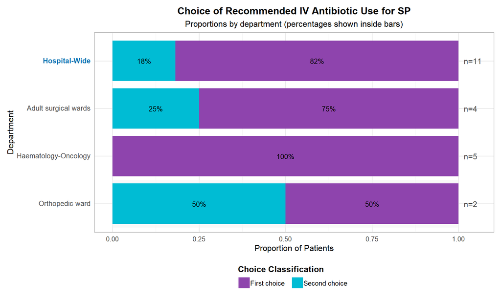

**💡 Note:** Patients who received metronidazole alone were not included in this analysis, as it serves as adjunct therapy for anaerobic coverage and does not independently define the prophylaxis choice for SP according to the WHO AWaRe Book.

## 📝 Summary of SP Antibiotic Choice Appropriateness

This section summarises the proportion of SP antibiotic choice appropriateness across hospital departments based on the WHO AWaRe Book.

💊 **Denominator:** Number of eligible SP patients who received any IV antibiotic (**19** out of **21**)

**Summary:**

**🏥 Hospital-Wide** (n = 19 patients)

- ✅ **Received recommended IV antibiotics** (as per WHO AWaRe Book): **52.6%** (10 out of 19)
- ⚠️ **Partially received recommended IV antibiotics** (as per WHO AWaRe Book): **10.5%** (2 out of 19)
- ❌ **Received IV antibiotics not among recommended options** (as per WHO AWaRe Book): **36.8%** (7 out of 19)

**🏥 Adult surgical wards** (n = 4 patients)

- ✅ **Received recommended IV antibiotics** (as per WHO AWaRe Book): **100.0%** (4 out of 4)
- ⚠️ **Partially received recommended IV antibiotics** (as per WHO AWaRe Book): **0.0%** (0 out of 4)
- ❌ **Received IV antibiotics not among recommended options** (as per WHO AWaRe Book): **0.0%** (0 out of 4)

**🏥 General Medical Ward** (n = 4 patients)

- ✅ **Received recommended IV antibiotics** (as per WHO AWaRe Book): **0.0%** (0 out of 4)
- ⚠️ **Partially received recommended IV antibiotics** (as per WHO AWaRe Book): **25.0%** (1 out of 4)
- ❌ **Received IV antibiotics not among recommended options** (as per WHO AWaRe Book): **75.0%** (3 out of 4)

**🏥 Haematology-Oncology** (n = 5 patients)

- ✅ **Received recommended IV antibiotics** (as per WHO AWaRe Book): **100.0%** (5 out of 5)
- ⚠️ **Partially received recommended IV antibiotics** (as per WHO AWaRe Book): **0.0%** (0 out of 5)
- ❌ **Received IV antibiotics not among recommended options** (as per WHO AWaRe Book): **0.0%** (0 out of 5)

**🏥 Orthopedic ward** (n = 6 patients)

- ✅ **Received recommended IV antibiotics** (as per WHO AWaRe Book): **16.7%** (1 out of 6)
- ⚠️ **Partially received recommended IV antibiotics** (as per WHO AWaRe Book): **16.7%** (1 out of 6)
- ❌ **Received IV antibiotics not among recommended options** (as per WHO AWaRe Book): **66.7%** (4 out of 6)

## 📈 SP Antibiotic Choice & Dosage Appropriateness

This visual summarises SP dosage appropriateness across hospital departments based on WHO AWaRe Book

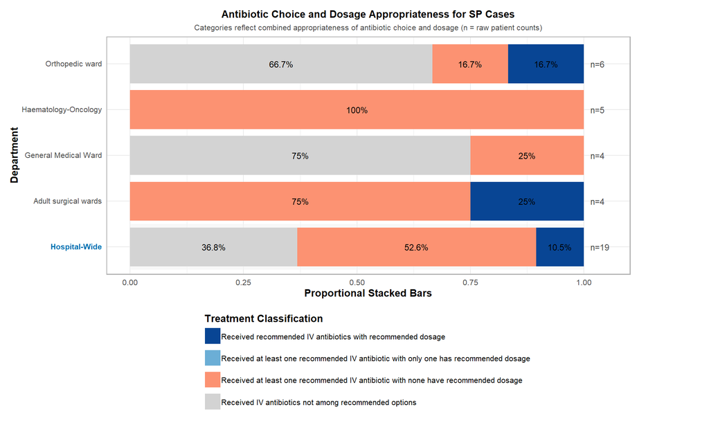

**💡 Notes:**

- **Received recommended IV antibiotics with recommended dosage** indicates that the full recommended prophylaxis regimen (whether monotherapy or dual therapy) was given, with all dosages aligned with WHO AWaRe Book guidance.
- **Received at least one recommended IV antibiotic with one has recommended dosage** refers to cases where only part of the recommended dual therapy was given, and only one antibiotic was at the recommended dosage.
- **Received at least one recommended IV antibiotic with none have recommended dosage** includes cases who received either the full recommended regimen with no recommended dosages, or only part of it (e.g., one agent from a dual therapy) with none of the dosages aligned with WHO AWaRe Book guidance.

## 📝 Summary of SP Antibiotic Choice & Dosage Appropriateness

This section evaluates the appropriateness of IV antibiotic drug dosage for patients on SP, in line with the WHO AWaRe Book guidance.

💊 **Denominator:** Number of eligible SP patients who received recommended (*or partially recommended*) IV antibiotic choice based on WHO AWaRe Book (**12** out of 21)

**Summary:**

**🏥 Hospital-Wide** (n = 12 patients)

- ✅ **Received recommended IV antibiotics with recommended dosage** (as per WHO AWaRe Book): **16.7%** (2 out of 12)
- ⚠️ **Received at least one recommended IV antibiotic with only one has recommended dosage** (as per WHO AWaRe Book): **0.0%** (0 out of 12)
- ❌ **Received at least one recommended IV antibiotic with none have recommended dosage** (as per WHO AWaRe Book): **83.3%** (10 out of 12)

**🏥 Adult surgical wards** (n = 4 patients)

- ✅ **Received recommended IV antibiotics with recommended dosage** (as per WHO AWaRe Book): **25.0%** (1 out of 4)
- ⚠️ **Received at least one recommended IV antibiotic with only one has recommended dosage** (as per WHO AWaRe Book): **0.0%** (0 out of 4)
- ❌ **Received at least one recommended IV antibiotic with none have recommended dosage** (as per WHO AWaRe Book): **75.0%** (3 out of 4)

**🏥 General Medical Ward** (n = 1 patients)

- ✅ **Received recommended IV antibiotics with recommended dosage** (as per WHO AWaRe Book): **0.0%** (0 out of 1)
- ⚠️ **Received at least one recommended IV antibiotic with only one has recommended dosage** (as per WHO AWaRe Book): **0.0%** (0 out of 1)
- ❌ **Received at least one recommended IV antibiotic with none have recommended dosage** (as per WHO AWaRe Book): **100.0%** (1 out of 1)

**🏥 Haematology-Oncology** (n = 5 patients)

- ✅ **Received recommended IV antibiotics with recommended dosage** (as per WHO AWaRe Book): **0.0%** (0 out of 5)
- ⚠️ **Received at least one recommended IV antibiotic with only one has recommended dosage** (as per WHO AWaRe Book): **0.0%** (0 out of 5)
- ❌ **Received at least one recommended IV antibiotic with none have recommended dosage** (as per WHO AWaRe Book): **100.0%** (5 out of 5)

**🏥 Orthopedic ward** (n = 2 patients)

- ✅ **Received recommended IV antibiotics with recommended dosage** (as per WHO AWaRe Book): **50.0%** (1 out of 2)
- ⚠️ **Received at least one recommended IV antibiotic with only one has recommended dosage** (as per WHO AWaRe Book): **0.0%** (0 out of 2)
- ❌ **Received at least one recommended IV antibiotic with none have recommended dosage** (as per WHO AWaRe Book): **50.0%** (1 out of 2)